# work_normalization-etc_rough-draft_NNS

### Record tibble `t_fc`’s positional information in a `GRanges` object

`pos_info` will be used in `DESeq2` processing, post-processing, etc.

```r
pos_info <- GenomicRanges::GRanges(
    seqnames = t_fc$chr,
    ranges = IRanges::IRanges(t_fc$start, t_fc$end),
    strand = t_fc$strand,
    length = t_fc$length,
    feature = t_fc$feature,
    type = t_fc$type,
    genome = t_fc$genome
)
pos_info
```

## Perform normalization and run DGE analyses

### Perform prep work

#### Establish table of variables for `dds`—i.e., a “master” model matrix

- `dds` stands for *“DESeq2 dataset”* and is a `DESeqDataSet` object
- variables for `dds` are
  - `strain`
  - `state`
  - `time`
  - `kit` *(`tcn` for “Tecan”, `ovn` for “Ovation”)*
  - `transcription` *(`N` for “nascent”, `SS` for “steady state”)*
  - `auxin`
  - `timecourse`
  - `replicate`

```r
#  Columns ten through to the last column are composed of sample feature
#+ counts; get these column names into a vector
samples <- colnames(t_fc)[10:length(colnames(t_fc))]

#  Convert the vector of column names to a list by splitting each element at
#+ its underscores; thus, each vector element becomes a list of eight strings,
#+ with one string for 'strain', one for 'state', etc.; these
samples <- stringr::str_split(samples, "_")

#  Convert the list to a df, transpose it, then convert it to a tibble
#+ (R fun fact: 'tibble' data types can't be built directly from list data
#+ types)
samples <- samples %>%
    as.data.frame(
        .,
        #  Using numeric column names here because the columns will soon be
        #+ transposed to rows, and I don't want the rows to have proper names
        col.names = c(seq(1, 55)),
        #  Using proper row names here because the rows will soon be transposed
        #+ to columns, and I *do* want the columns to have proper names
        row.names = c(
            "strain", "state", "time", "kit", "transcription", "auxin",
            "timecourse", "replicate"
        )
    ) %>%
    t() %>%
    tibble::as_tibble()

#  Add a keys variable for quickly accessing combinations of variable values
keys <- vector(mode = "character")
for(i in seq(1, nrow(samples))) {
    # i <- 1
    keys[i] <- paste(
        samples[i, 1], samples[i, 2], samples[i, 3], samples[i, 4],
        samples[i, 5], samples[i, 6], samples[i, 7], samples[i, 8],
        sep = "_"
    )
}
keys <- keys %>% as.data.frame()
colnames(keys) <- "keys"

samples <- dplyr::bind_cols(samples, keys) %>%
    dplyr::relocate("keys", .before = "strain")

rm(i)

#  Add Alison's original samples names to the 'samples' dataframe using the
#+ 't_xl' dataframe; here, we're just adding the original sample names, but we
#+ could potentially add in other information stored in the Excel file
t_xl <- t_xl %>%
    dplyr::rename(keys = name) %>%
    dplyr::select(., c(keys, sample_name))
samples <- dplyr::full_join(samples, t_xl, by = "keys")

#  Convert all columns to data type 'factor' (having the variable values as
#+ factors helps with running DESeq2::DESeqDataSetFromMatrix() below)
samples[sapply(samples, is.character)] <- lapply(
    samples[sapply(samples, is.character)], as.factor
)

#  How does it look?
samples
```

| keys | strain | state | time | kit | transcription | auxin | timecourse | replicate | sample_name |
| --- | --- | --- | --- | --- | --- | --- | --- | --- | --- |
| n3-d_Q_day7_tcn_N_aux-T_tc-F_rep1 | n3-d | Q | day7 | tcn | N | aux-T | tc-F | rep1 | CT8_7716_pIAA_Q_Nascent |
| n3-d_Q_day7_tcn_N_aux-T_tc-F_rep2 | n3-d | Q | day7 | tcn | N | aux-T | tc-F | rep2 | CT10_7718_pIAA_Q_Nascent |
| n3-d_Q_day7_tcn_N_aux-T_tc-F_rep3 | n3-d | Q | day7 | tcn | N | aux-T | tc-F | rep3 | CT6_7714_pIAA_Q_Nascent |
| n3-d_Q_day7_tcn_SS_aux-T_tc-F_rep1 | n3-d | Q | day7 | tcn | SS | aux-T | tc-F | rep1 | CT8_7716_pIAA_Q_SteadyState |
| n3-d_Q_day7_tcn_SS_aux-T_tc-F_rep2 | n3-d | Q | day7 | tcn | SS | aux-T | tc-F | rep2 | CT10_7718_pIAA_Q_SteadyState |
| n3-d_Q_day7_tcn_SS_aux-T_tc-F_rep3 | n3-d | Q | day7 | tcn | SS | aux-T | tc-F | rep3 | CT6_7714_pIAA_Q_SteadyState |
| o-d_Q_day7_tcn_N_aux-T_tc-F_rep1 | o-d | Q | day7 | tcn | N | aux-T | tc-F | rep1 | CT2_6125_pIAA_Q_Nascent |
| o-d_Q_day7_tcn_N_aux-T_tc-F_rep2 | o-d | Q | day7 | tcn | N | aux-T | tc-F | rep2 | CT4_6126_pIAA_Q_Nascent |
| o-d_Q_day7_tcn_SS_aux-T_tc-F_rep1 | o-d | Q | day7 | tcn | SS | aux-T | tc-F | rep1 | CT2_6125_pIAA_Q_SteadyState |
| o-d_Q_day7_tcn_SS_aux-T_tc-F_rep2 | o-d | Q | day7 | tcn | SS | aux-T | tc-F | rep2 | CT4_6126_pIAA_Q_SteadyState |

[output cut: 45 more lines]

```r
rm(t_xl, keys)
```

#### Make the counts matrix

```r
datasets <- c(
    "n3-d_Q_day7_tcn_N_aux-T_tc-F_rep1",
    "n3-d_Q_day7_tcn_N_aux-T_tc-F_rep2",
    "n3-d_Q_day7_tcn_N_aux-T_tc-F_rep3",
    "n3-d_Q_day7_tcn_SS_aux-T_tc-F_rep1",
    "n3-d_Q_day7_tcn_SS_aux-T_tc-F_rep2",
    "n3-d_Q_day7_tcn_SS_aux-T_tc-F_rep3"
)
counts_data <- t_fc[, colnames(t_fc) %in% datasets] %>%
    as.data.frame()  #IMPORTANT Output a dataframe, not a tibble

#  How do things look?
counts_data
```

| n3-d_Q_day7_tcn_N_aux-T_tc-F_rep1 | n3-d_Q_day7_tcn_N_aux-T_tc-F_rep2 | n3-d_Q_day7_tcn_N_aux-T_tc-F_rep3 | n3-d_Q_day7_tcn_SS_aux-T_tc-F_rep1 | n3-d_Q_day7_tcn_SS_aux-T_tc-F_rep2 | n3-d_Q_day7_tcn_SS_aux-T_tc-F_rep3 |
| --- | --- | --- | --- | --- | --- |
| 5 | 0 | 2 | 0 | 1 | 1 |
| 2 | 2 | 0 | 0 | 0 | 0 |
| 27 | 22 | 21 | 8 | 11 | 6 |
| 1 | 0 | 1 | 0 | 0 | 0 |
| 310 | 197 | 230 | 69 | 62 | 46 |
| 67 | 53 | 73 | 21 | 14 | 12 |
| 116 | 71 | 99 | 50 | 23 | 15 |
| 324 | 238 | 295 | 98 | 87 | 70 |
| 200 | 122 | 147 | 54 | 40 | 33 |
| 161 | 120 | 109 | 38 | 30 | 15 |

[output cut: 990 more lines]

#### Make the model matrix

```r
#  Use the "keys" column to isolate WT G1 and Q Ovation 4tU-seq datasets
#REMEMBER Variable `datasets` is initialized in the preceding chunk
col_data <- samples[samples$keys %in% datasets, ] %>%
    as.data.frame() %>%    #IMPORTANT Output a dataframe, not a tibble
    tibble::column_to_rownames(., var = "keys")  #IMPORTANT Have row names

#  How do things look?
col_data
```

|  | strain | state | time | kit | transcription | auxin | timecourse | replicate | sample_name |
| --- | --- | --- | --- | --- | --- | --- | --- | --- | --- |
| n3-d_Q_day7_tcn_N_aux-T_tc-F_rep1 | n3-d | Q | day7 | tcn | N | aux-T | tc-F | rep1 | CT8_7716_pIAA_Q_Nascent |
| n3-d_Q_day7_tcn_N_aux-T_tc-F_rep2 | n3-d | Q | day7 | tcn | N | aux-T | tc-F | rep2 | CT10_7718_pIAA_Q_Nascent |
| n3-d_Q_day7_tcn_N_aux-T_tc-F_rep3 | n3-d | Q | day7 | tcn | N | aux-T | tc-F | rep3 | CT6_7714_pIAA_Q_Nascent |
| n3-d_Q_day7_tcn_SS_aux-T_tc-F_rep1 | n3-d | Q | day7 | tcn | SS | aux-T | tc-F | rep1 | CT8_7716_pIAA_Q_SteadyState |
| n3-d_Q_day7_tcn_SS_aux-T_tc-F_rep2 | n3-d | Q | day7 | tcn | SS | aux-T | tc-F | rep2 | CT10_7718_pIAA_Q_SteadyState |
| n3-d_Q_day7_tcn_SS_aux-T_tc-F_rep3 | n3-d | Q | day7 | tcn | SS | aux-T | tc-F | rep3 | CT6_7714_pIAA_Q_SteadyState |

#### Make the `DESeqDataSet`, `dds`

- Use `counts_data` for the `featureCount` tallies
- Use `col_data` for setting up the GLM
- Use `pos_info` for adding feature metadata, subsequent subsetting, etc.

```r
dds <- DESeq2::DESeqDataSetFromMatrix(
    countData = counts_data,
    colData = col_data,
    design = ~ transcription,
    rowRanges = pos_info
)

#  Make a back-up of the DESeqDataSet object
bak.dds <- dds

#  How do things look?
# dds %>% BiocGenerics::counts() %>% head()
# dds@rowRanges
# dds@design
# dds@assays
```

#### Prefilter `dds`

We probably don’t need to do this, but then again we may want to; `#TODO` Let’s make a decision later.

```r
# threshold <- 0
# dds_filt <- dds[rowSums(BiocGenerics::counts(dds)) >= threshold, ]
#
#  Breakdown
#    0 13166
#   10 11893
#   50 11049
#  100 10645
#  500 8601
# 1000 6738
#
# rm(threshold, dds_filt)
```

## I. Run analyses with *S. cerevisae* features only

### Perform size-factor estimation

Here, we subset out the *K. lactis* features. Thus, we are using only *S. cerevisiae* features in the size-factor estimation. No control genes are used.

```r
dds_SC <- BiocGenerics::estimateSizeFactors(
    dds[dds@rowRanges$genome != "K_lactis", ]
)
dds_SC@colData
```

```
DataFrame with 6 rows and 10 columns
                                     strain    state     time      kit transcription    auxin timecourse replicate                  sample_name
                                   <factor> <factor> <factor> <factor>      <factor> <factor>   <factor>  <factor>                     <factor>
n3-d_Q_day7_tcn_N_aux-T_tc-F_rep1      n3-d        Q     day7      tcn            N     aux-T       tc-F      rep1 CT8_7716_pIAA_Q_Nascent
n3-d_Q_day7_tcn_N_aux-T_tc-F_rep2      n3-d        Q     day7      tcn            N     aux-T       tc-F      rep2 CT10_7718_pIAA_Q_Nascent
n3-d_Q_day7_tcn_N_aux-T_tc-F_rep3      n3-d        Q     day7      tcn            N     aux-T       tc-F      rep3 CT6_7714_pIAA_Q_Nascent
n3-d_Q_day7_tcn_SS_aux-T_tc-F_rep1     n3-d        Q     day7      tcn            SS    aux-T       tc-F      rep1 CT8_7716_pIAA_Q_SteadyState
n3-d_Q_day7_tcn_SS_aux-T_tc-F_rep2     n3-d        Q     day7      tcn            SS    aux-T       tc-F      rep2 CT10_7718_pIAA_Q_SteadyState
n3-d_Q_day7_tcn_SS_aux-T_tc-F_rep3     n3-d        Q     day7      tcn            SS    aux-T       tc-F      rep3 CT6_7714_pIAA_Q_SteadyState
                                   sizeFactor
                                    <numeric>
n3-d_Q_day7_tcn_N_aux-T_tc-F_rep1    1.914013
n3-d_Q_day7_tcn_N_aux-T_tc-F_rep2    1.489813
n3-d_Q_day7_tcn_N_aux-T_tc-F_rep3    2.061973
n3-d_Q_day7_tcn_SS_aux-T_tc-F_rep1   0.695266
n3-d_Q_day7_tcn_SS_aux-T_tc-F_rep2   0.497825
n3-d_Q_day7_tcn_SS_aux-T_tc-F_rep3   0.505492
```

```r
# Q N rep1 1.914013
# Q N rep2 1.489813
# Q N rep3 2.061973
# Q SS rep1 0.695266
# Q SS rep2 0.497825
# Q SS rep3 0.505492
```

### Run `DESeq2`

#### Call `DESeq2` using default parameters

```r
dds_SC <- DESeq2::DESeq(dds_SC)

#  Check model information
DESeq2::resultsNames(dds_SC)[2]
#  [1] "transcription_SS_vs_N"
#+ Thus, the model varies on transcription, SS is the numerator, N is the
#+ denominator
```

#### Call `DESeq2::results()`

```r
#  Set up necessary parameters for generation of DESeq2 results table
independent_filtering <- TRUE
threshold_p <- 0.05
threshold_lfc <- 0

#  Output a DESeq2 DataFrame object
DGE_unshrunken_DF_SC <- DESeq2::results(
    dds_SC,
    name = DESeq2::resultsNames(dds_SC)[2],
    independentFiltering = independent_filtering,
    alpha = threshold_p,
    lfcThreshold = threshold_lfc,
    format = "DataFrame"
)

#  Output a GRanges object, which we can easily add to and convert to other
#+ formats (such as a tibble)
DGE_unshrunken_GR_SC <- DESeq2::results(
    dds_SC,
    name = DESeq2::resultsNames(dds_SC)[2],
    independentFiltering = independent_filtering,
    alpha = threshold_p,
    lfcThreshold = threshold_lfc,
    format = "GRanges"
)
DGE_unshrunken_GR_SC$feature <- MatrixGenerics::rowRanges(dds_SC)$feature
DGE_unshrunken_GR_SC$type <- MatrixGenerics::rowRanges(dds_SC)$type
DGE_unshrunken_GR_SC$genome <- MatrixGenerics::rowRanges(dds_SC)$genome

t_DGE_SC <- DGE_unshrunken_GR_SC %>%
    dplyr::as_tibble() %>%
    dplyr::rename(chr = seqnames)

rm(independent_filtering, threshold_p, threshold_lfc)
```

#### Make an MA plot that colors features by independent filtering

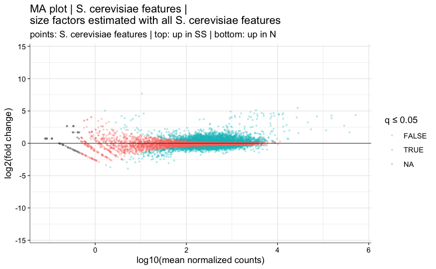

```r
#  Set up temporary variable 'tbl', which will be passed to ggplot
tbl <- t_DGE_SC
tbl <- tbl[with(tbl, order(log2FoldChange)), ]
tbl$threshold <- as.factor(tbl$padj <= 0.05)
tbl$log10baseMean <- ifelse(
    is.infinite(log10(tbl$baseMean)), NA, log10(tbl$baseMean)
)

title <- paste0(
    "MA plot | S. cerevisiae features |\n",
    "size factors estimated with all S. cerevisiae features"
)
subtitle <- paste(
    "points: S. cerevisiae features",
    "| top: up in SS",
    "| bottom: up in N"
)  # [1] "transcription_SS_vs_N"
ggplot(tbl, aes(x = log10baseMean, y = log2FoldChange, colour = threshold)) +
    geom_point(alpha = 0.25, size = 0.5) +
    # geom_hline(aes(yintercept = 0), colour = "#000000", linewidth = 0.25) +
    geom_hline(aes(yintercept = 0), colour = "#000000", size = 0.25) +
    # ylim(c(min(tbl$log2FoldChange), max(tbl$log2FoldChange))) +
    ylim(c(-14, 14)) +
    xlab("log10(mean normalized counts)") +
    ylab("log2(fold change)") +
    scale_colour_discrete(name = "q ≤ 0.05") +
    ggtitle(title, subtitle) +
    theme_slick
```

```r
#TODO 1/2 Explain and make a decision regarding use of 'size' or 'linewidth'
#TODO 2/2 parameters

#  Create a vector of features that both passed independent filtering (and thus
#+ have an inherently high mean expression) and are not statistically
#+ significant; this vector signifies features that are "stably expressed"
#+ between conditions
tbl$stably_expressed <- ifelse(
    !is.na(tbl$threshold) & tbl$padj > 0.05,
    TRUE,
    FALSE
)
stably_expressed_SC <- tbl$feature[tbl$stably_expressed == TRUE]

rm(tbl, title, subtitle)
```

#### Make a volcano plot

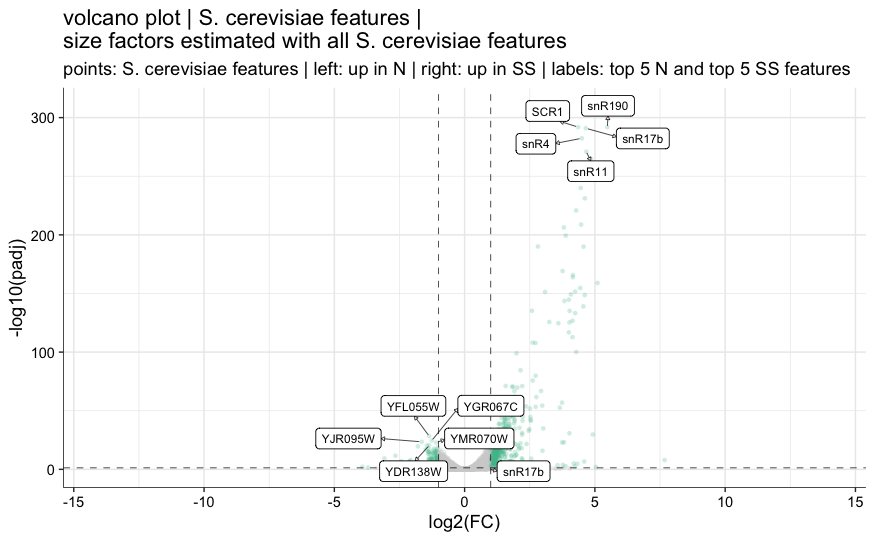

```r
#  Identify and isolate the top 5 upregulated features and the top 5 down-
#+ regulated features
all <- t_DGE_SC$feature
selection_down <- t_DGE_SC %>%
    dplyr::filter(log2FoldChange < 0) %>%
    dplyr::arrange(padj) %>%
    dplyr::slice(1:5)
selection_up <- t_DGE_SC %>%
    dplyr::filter(log2FoldChange > 0) %>%
    dplyr::arrange(padj) %>%
    dplyr::slice(1:5)
selection <- c(selection_down[["feature"]], selection_up[["feature"]]) %>%
        as.character()

title <- paste0(
    "volcano plot | S. cerevisiae features |\n",
    "size factors estimated with all S. cerevisiae features"
)
subtitle <- paste(
    "points: S. cerevisiae features",
    "| left: up in N",
    "| right: up in SS",
    "| labels: top 5 N and top 5 SS features"
)  # [1] "transcription_SS_vs_N"
p_SC <- plot_volcano(
    table = t_DGE_SC,
    label = all,
    selection = selection,
    label_size = 2.5,
    p_cutoff = 0.05,
    FC_cutoff = 1,
    xlim = c(-14, 14),
    ylim = c(0, 310),
    color = "#52BE9B",
    title = title,
    subtitle = subtitle
)
p_SC
```

```r
# save_volcano(
#     file = "test.pdf",
#     plot = p,
#     width = 2,
#     height = 3
# )

rm(all, selection, selection_up, selection_down, title, subtitle)
```

## II. Run analyses with *K. lactis* features only

### Perform size-factor estimation

Here, we subset out—i.e., remove—the *S. cerevisiae* features and are thus only analyzing *K. lactis* features, using all *K. lactis* features in the size-factor estimation.

```r
dds_KL <- BiocGenerics::estimateSizeFactors(
    dds[dds@rowRanges$genome != "S_cerevisiae", ]
)
dds_KL@colData
# Q N rep1 6.264768
# Q N rep2 7.190513
# Q N rep3 6.525544
# Q SS rep1 0.161401
# Q SS rep2 0.165265
# Q SS rep3 0.140550
```

### Run `DESeq2`

#### Call `DESeq2` using default parameters

```r
dds_KL <- DESeq2::DESeq(dds_KL)

#  Check model information
DESeq2::resultsNames(dds_KL)[2]
#  [1] "transcription_SS_vs_N"
#+ Thus, the model varies on transcription, SS is the numerator, N is the
#+ denominator
```

#### Call `DESeq2::results()`

```r
#  Set up necessary parameters for generation of DESeq2 results table
independent_filtering <- TRUE
threshold_p <- 0.05
threshold_lfc <- 0

#  Output a DESeq2 DataFrame object
DGE_unshrunken_DF_KL <- DESeq2::results(
    dds_KL,
    name = DESeq2::resultsNames(dds_KL)[2],
    independentFiltering = independent_filtering,
    alpha = threshold_p,
    lfcThreshold = threshold_lfc,
    format = "DataFrame"
)

#  Output a GRanges object, which we can easily add to and convert to other
#+ formats (such as a tibble)
DGE_unshrunken_GR_KL <- DESeq2::results(
    dds_KL,
    name = DESeq2::resultsNames(dds_KL)[2],
    independentFiltering = independent_filtering,
    alpha = threshold_p,
    lfcThreshold = threshold_lfc,
    format = "GRanges"
)
DGE_unshrunken_GR_KL$feature <- MatrixGenerics::rowRanges(dds_KL)$feature
DGE_unshrunken_GR_KL$type <- MatrixGenerics::rowRanges(dds_KL)$type
DGE_unshrunken_GR_KL$genome <- MatrixGenerics::rowRanges(dds_KL)$genome

t_DGE_KL <- DGE_unshrunken_GR_KL %>%
    dplyr::as_tibble() %>%
    dplyr::rename(chr = seqnames)

rm(independent_filtering, threshold_p, threshold_lfc)
```

#### Make an MA plot that colors features by independent filtering

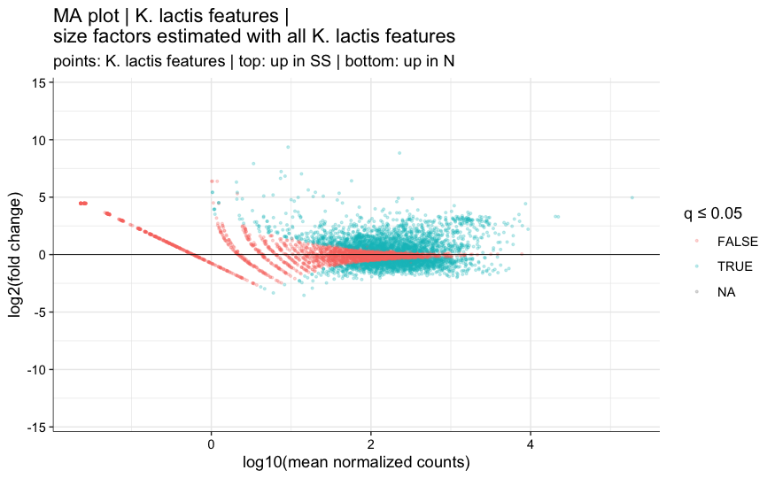

```r
#  Set up temporary variable 'tbl', which will be passed to ggplot
tbl <- t_DGE_KL
tbl <- tbl[with(tbl, order(log2FoldChange)), ]
tbl$threshold <- as.factor(tbl$padj <= 0.05)
tbl$log10baseMean <- ifelse(
    is.infinite(log10(tbl$baseMean)), NA, log10(tbl$baseMean)
)

title <- paste0(
    "MA plot | K. lactis features |\n",
    "size factors estimated with all K. lactis features"
)
subtitle <- paste(
    "points: K. lactis features",
    "| top: up in SS",
    "| bottom: up in N"
)  # [1] "transcription_SS_vs_N"
ggplot(tbl, aes(x = log10baseMean, y = log2FoldChange, colour = threshold)) +
    geom_point(alpha = 0.25, size = 0.5) +
    # geom_hline(aes(yintercept = 0), colour = "#000000", linewidth = 0.25) +
    geom_hline(aes(yintercept = 0), colour = "#000000", size = 0.25) +
    # ylim(c(min(tbl$log2FoldChange), max(tbl$log2FoldChange))) +
    ylim(c(-14, 14)) +
    xlab("log10(mean normalized counts)") +
    ylab("log2(fold change)") +
    scale_colour_discrete(name = "q ≤ 0.05") +
    ggtitle(title, subtitle) +
    theme_slick
```

```r
#TODO 1/2 Explain and make a decision regarding use of 'size' or 'linewidth'
#TODO 2/2 parameters

#  Create a vector of features that both passed independent filtering (and thus
#+ have an inherently high mean expression) and are not statistically
#+ significant; this vector signifies features that are "stably expressed"
#+ between conditions
tbl$stably_expressed <- ifelse(
    !is.na(tbl$threshold) & tbl$padj > 0.05,
    TRUE,
    FALSE
)
stably_expressed_KL <- tbl$feature[tbl$stably_expressed == TRUE]
#NOTE Probably need to be more stringent here

rm(tbl, title, subtitle)
```